# HW5_Sol

Safanah, Saksham, and Amir

4/20/2022

```r
knitr::opts_chunk$set(echo = TRUE)

# Uploading the data

# Raw data
Raw_Data <- read.csv("C:/Users/ssoman3/Desktop/UIC Spring 2022/Data Mining/Assignment 5/updatedrmarkdown/Raw_Data.csv")

# Samples data

Q3Data <- read.csv("C:/Users/ssoman3/Desktop/UIC Spring 2022/Data Mining/Assignment 5/updatedrmarkdown/Q3Data.csv")
```

**The concern here is the samples data more than the order data, because for orders they were already placed by customers, but for samples we are aiming to predict conversion and to cluster the customers**

```r
# uploading required libraries
library(tidyverse)
library(dplyr)
library(ggplot2)
library(corrplot)
library(rpart)
library(ISLR)
library(caret)
library(randomForest)
library(glm2)
library(skimr)
library(glm2)
library(nnet)
library(JOUSBoost)
library(ROSE)
library(factoextra)
library(gridExtra)
library(spaa)
```

### 1) Data Visualization (Explatory Data Analsysis)

**- There are 18955 observations in the Raw dataset, and 5820 for the samples only dataset**

**- Target variable = conversion , with two values 0 “No conversion”, 1 “conversion”**

```r
dim(Raw_Data)
```

```
## [1] 18955    16
```

```r
dim(Q3Data)
```

```
## [1] 5820   25
```

```r
colnames(Raw_Data)
```

```
##  [1] "OrderType"       "OrderCategory"   "CustomerCode"    "CountryName"
##  [5] "CustomerOrderNo" "Custorderdate"   "UnitName"        "QtyRequired"
##  [9] "TotalArea"       "Amount"          "ITEM_NAME"       "QualityName"
## [13] "DesignName"      "ColorName"       "ShapeName"       "AreaFt"
```

```r
colnames(Q3Data)
```

```
##  [1] "CustomerCode"     "CountryName"      "USA"              "UK"
##  [5] "Italy"            "Belgium"          "Romania"          "Australia"
##  [9] "India"            "QtyRequired"      "ITEM_NAME"        "Hand.Tufted"
## [13] "Durry"            "Double.Back"      "Hand.Woven"       "Knotted"
## [17] "Jacquard"         "Handloom"         "Other"            "ShapeName"
## [21] "REC"              "Round"            "Square"           "AreaFt"
## [25] "Order.Conversion"
```

```r
unique(Q3Data$Order.Conversion)
```

```
## [1] 1 0
```

**There are no missing data as shown in by the function below in both raw data and samples only data**

```r
colSums(is.na(Raw_Data))
```

```
##       OrderType   OrderCategory    CustomerCode     CountryName CustomerOrderNo
##               0               0               0               0               0
##   Custorderdate        UnitName     QtyRequired       TotalArea          Amount
##               0               0               0               0               0
##       ITEM_NAME     QualityName      DesignName       ColorName       ShapeName
##               0               0               0               0               0
##          AreaFt
##               0
```

```r
colSums(is.na(Q3Data))
```

```
##     CustomerCode      CountryName              USA               UK
##                0                0                0                0
##            Italy          Belgium          Romania        Australia
##                0                0                0                0
##            India      QtyRequired        ITEM_NAME      Hand.Tufted
##                0                0                0                0
##            Durry      Double.Back       Hand.Woven          Knotted
##                0                0                0                0
##         Jacquard         Handloom            Other        ShapeName
##                0                0                0                0
##              REC            Round           Square           AreaFt
##                0                0                0                0
## Order.Conversion
##                0
```

**- Checking the min, max, mean of each variable**

```r
summary(Raw_Data)
```

```
##   OrderType         OrderCategory      CustomerCode       CountryName
##  Length:18955       Length:18955       Length:18955       Length:18955
##  Class :character   Class :character   Class :character   Class :character
##  Mode  :character   Mode  :character   Mode  :character   Mode  :character
##
##
##
##  CustomerOrderNo    Custorderdate        UnitName          QtyRequired
##  Length:18955       Length:18955       Length:18955       Min.   :   1.00
##  Class :character   Class :character   Class :character   1st Qu.:   1.00
##  Mode  :character   Mode  :character   Mode  :character   Median :   4.00
##                                                           Mean   :  31.42
##                                                           3rd Qu.:  13.00
##                                                           Max.   :6400.00
##    TotalArea           Amount          ITEM_NAME         QualityName
##  Min.   :   0.04   Min.   :     0.0   Length:18955       Length:18955
##  1st Qu.:   4.00   1st Qu.:     0.0   Class :character   Class :character
##  Median :  15.00   Median :   200.6   Mode  :character   Mode  :character
##  Mean   :  36.15   Mean   :  1657.6
##  3rd Qu.:  54.00   3rd Qu.:   977.1
##  Max.   :1024.00   Max.   :599719.7
##   DesignName         ColorName          ShapeName             AreaFt
##  Length:18955       Length:18955       Length:18955       Min.   :  0.4444
##  Class :character   Class :character   Class :character   1st Qu.:  8.4375
##  Mode  :character   Mode  :character   Mode  :character   Median : 35.0000
##                                                           Mean   : 44.4695
##                                                           3rd Qu.: 64.7361
##                                                           Max.   :645.7222
```

```r
summary(Q3Data)
```

```
##  CustomerCode       CountryName             USA               UK
##  Length:5820        Length:5820        Min.   :0.0000   Min.   :0.00000
##  Class :character   Class :character   1st Qu.:0.0000   1st Qu.:0.00000
##  Mode  :character   Mode  :character   Median :0.0000   Median :0.00000
##                                        Mean   :0.2474   Mean   :0.03488
##                                        3rd Qu.:0.0000   3rd Qu.:0.00000
##                                        Max.   :1.0000   Max.   :1.00000
##      Italy             Belgium           Romania           Australia
##  Min.   :0.000000   Min.   :0.00000   Min.   :0.000000   Min.   :0.000000
##  1st Qu.:0.000000   1st Qu.:0.00000   1st Qu.:0.000000   1st Qu.:0.000000
##  Median :0.000000   Median :0.00000   Median :0.000000   Median :0.000000
##  Mean   :0.007732   Mean   :0.02268   Mean   :0.003436   Mean   :0.001718
##  3rd Qu.:0.000000   3rd Qu.:0.00000   3rd Qu.:0.000000   3rd Qu.:0.000000
##  Max.   :1.000000   Max.   :1.00000   Max.   :1.000000   Max.   :1.000000
##      India         QtyRequired       ITEM_NAME          Hand.Tufted
##  Min.   :0.0000   Min.   :  1.000   Length:5820        Min.   :0.0000
##  1st Qu.:0.0000   1st Qu.:  1.000   Class :character   1st Qu.:0.0000
##  Median :1.0000   Median :  1.000   Mode  :character   Median :0.0000
##  Mean   :0.6771   Mean   :  1.975                      Mean   :0.4167
##  3rd Qu.:1.0000   3rd Qu.:  1.000                      3rd Qu.:1.0000
##  Max.   :1.0000   Max.   :200.000                      Max.   :1.0000
##      Durry         Double.Back        Hand.Woven        Knotted
##  Min.   :0.0000   Min.   :0.00000   Min.   :0.0000   Min.   :0.00000
##  1st Qu.:0.0000   1st Qu.:0.00000   1st Qu.:0.0000   1st Qu.:0.00000
##  Median :0.0000   Median :0.00000   Median :0.0000   Median :0.00000
##  Mean   :0.2686   Mean   :0.09519   Mean   :0.1211   Mean   :0.03729
##  3rd Qu.:1.0000   3rd Qu.:0.00000   3rd Qu.:0.0000   3rd Qu.:0.00000
##  Max.   :1.0000   Max.   :1.00000   Max.   :1.0000   Max.   :1.00000
##     Jacquard          Handloom          Other          ShapeName
##  Min.   :0.00000   Min.   :0.0000   Min.   :0.00000   Length:5820
##  1st Qu.:0.00000   1st Qu.:0.0000   1st Qu.:0.00000   Class :character
##  Median :0.00000   Median :0.0000   Median :0.00000   Mode  :character
##  Mean   :0.01443   Mean   :0.0177   Mean   :0.02904
##  3rd Qu.:0.00000   3rd Qu.:0.0000   3rd Qu.:0.00000
##  Max.   :1.00000   Max.   :1.0000   Max.   :1.00000
##       REC             Round              Square            AreaFt
##  Min.   :0.0000   Min.   :0.000000   Min.   :0.00000   Min.   :  0.6667
##  1st Qu.:1.0000   1st Qu.:0.000000   1st Qu.:0.00000   1st Qu.:  6.0000
##  Median :1.0000   Median :0.000000   Median :0.00000   Median : 11.0000
##  Mean   :0.9864   Mean   :0.009794   Mean   :0.00378   Mean   : 21.5558
##  3rd Qu.:1.0000   3rd Qu.:0.000000   3rd Qu.:0.00000   3rd Qu.: 39.8125
##  Max.   :1.0000   Max.   :1.000000   Max.   :1.00000   Max.   :480.0000
##  Order.Conversion
##  Min.   :0.0000
##  1st Qu.:0.0000
##  Median :0.0000
##  Mean   :0.2009
##  3rd Qu.:0.0000
##  Max.   :1.0000
```

**As we mentioned that the data we are working with is the (Samples Only) Data, hence it is important to check the indepdent variables types**

```r
str(Q3Data)
```

```
## 'data.frame':    5820 obs. of  25 variables:
##  $ CustomerCode    : chr  "CC" "M-1" "M-1" "M-1" ...
##  $ CountryName     : chr  "INDIA" "USA" "USA" "USA" ...
##  $ USA             : int  0 1 1 1 1 0 0 1 1 0 ...
##  $ UK              : int  0 0 0 0 0 0 0 0 0 0 ...
##  $ Italy           : int  0 0 0 0 0 0 0 0 0 0 ...
##  $ Belgium         : int  0 0 0 0 0 0 0 0 0 0 ...
##  $ Romania         : int  0 0 0 0 0 0 0 0 0 0 ...
##  $ Australia       : int  0 0 0 0 0 0 0 0 0 0 ...
##  $ India           : int  1 0 0 0 0 1 1 0 0 1 ...
##  $ QtyRequired     : int  1 1 2 1 1 1 1 1 1 1 ...
##  $ ITEM_NAME       : chr  "HAND TUFTED" "HAND TUFTED" "HAND TUFTED" "HAND TUFTED" ...
##  $ Hand.Tufted     : int  1 1 1 1 1 0 0 1 1 1 ...
##  $ Durry           : int  0 0 0 0 0 0 0 0 0 0 ...
##  $ Double.Back     : int  0 0 0 0 0 1 1 0 0 0 ...
##  $ Hand.Woven      : int  0 0 0 0 0 0 0 0 0 0 ...
##  $ Knotted         : int  0 0 0 0 0 0 0 0 0 0 ...
##  $ Jacquard        : int  0 0 0 0 0 0 0 0 0 0 ...
##  $ Handloom        : int  0 0 0 0 0 0 0 0 0 0 ...
##  $ Other           : int  0 0 0 0 0 0 0 0 0 0 ...
##  $ ShapeName       : chr  "REC" "REC" "REC" "REC" ...
##  $ REC             : int  1 1 1 1 1 1 1 1 1 1 ...
##  $ Round           : int  0 0 0 0 0 0 0 0 0 0 ...
##  $ Square          : int  0 0 0 0 0 0 0 0 0 0 ...
##  $ AreaFt          : num  80 80 80 80 80 80 80 40 108 54 ...
##  $ Order.Conversion: int  1 1 1 1 1 1 1 1 0 1 ...
```

**We can see that some of the variables types need to be changed. Hence, the following code changes their types to the correct ones**

```r
Q3Data$CountryName <- as.factor(Q3Data$CountryName)
Q3Data$ITEM_NAME <- as.factor(Q3Data$ITEM_NAME)
Q3Data$ShapeName<- as.factor(Q3Data$ShapeName)


str(Q3Data) # checking the types of the variables after the adjustment
```

```
## 'data.frame':    5820 obs. of  25 variables:
##  $ CustomerCode    : chr  "CC" "M-1" "M-1" "M-1" ...
##  $ CountryName     : Factor w/ 14 levels "AUSTRALIA","BELGIUM",..: 6 14 14 14 14 6 6 14 14 6 ...
##  $ USA             : int  0 1 1 1 1 0 0 1 1 0 ...
##  $ UK              : int  0 0 0 0 0 0 0 0 0 0 ...
##  $ Italy           : int  0 0 0 0 0 0 0 0 0 0 ...
##  $ Belgium         : int  0 0 0 0 0 0 0 0 0 0 ...
##  $ Romania         : int  0 0 0 0 0 0 0 0 0 0 ...
##  $ Australia       : int  0 0 0 0 0 0 0 0 0 0 ...
##  $ India           : int  1 0 0 0 0 1 1 0 0 1 ...
##  $ QtyRequired     : int  1 1 2 1 1 1 1 1 1 1 ...
##  $ ITEM_NAME       : Factor w/ 11 levels "DOUBLE BACK",..: 4 4 4 4 4 1 1 4 4 4 ...
##  $ Hand.Tufted     : int  1 1 1 1 1 0 0 1 1 1 ...
##  $ Durry           : int  0 0 0 0 0 0 0 0 0 0 ...
##  $ Double.Back     : int  0 0 0 0 0 1 1 0 0 0 ...
##  $ Hand.Woven      : int  0 0 0 0 0 0 0 0 0 0 ...
##  $ Knotted         : int  0 0 0 0 0 0 0 0 0 0 ...
##  $ Jacquard        : int  0 0 0 0 0 0 0 0 0 0 ...
##  $ Handloom        : int  0 0 0 0 0 0 0 0 0 0 ...
##  $ Other           : int  0 0 0 0 0 0 0 0 0 0 ...
##  $ ShapeName       : Factor w/ 3 levels "REC","ROUND",..: 1 1 1 1 1 1 1 1 1 1 ...
##  $ REC             : int  1 1 1 1 1 1 1 1 1 1 ...
##  $ Round           : int  0 0 0 0 0 0 0 0 0 0 ...
##  $ Square          : int  0 0 0 0 0 0 0 0 0 0 ...
##  $ AreaFt          : num  80 80 80 80 80 80 80 40 108 54 ...
##  $ Order.Conversion: int  1 1 1 1 1 1 1 1 0 1 ...
```

*We are predicting a categorical target variables which is the (Order.Conversion). So the type of models we will be building are the classification models*

**Showing the mean and the standard devation of the variables*

```r
skim(Q3Data)
```

Data summary

| Name | Q3Data |
| --- | --- |
| Number of rows | 5820 |
| Number of columns | 25 |
| _______________________ |  |
| Column type frequency: |  |
| character | 1 |
| factor | 3 |
| numeric | 21 |
| ________________________ |  |
| Group variables | None |

**Variable type: character**

| skim_variable | n_missing | complete_rate | min | max | empty | n_unique | whitespace |
| --- | --- | --- | --- | --- | --- | --- | --- |
| CustomerCode | 0 | 1 | 2 | 4 | 0 | 34 | 0 |

**Variable type: factor**

| skim_variable | n_missing | complete_rate | ordered | n_unique | top_counts |
| --- | --- | --- | --- | --- | --- |
| CountryName | 0 | 1 | FALSE | 14 | IND: 3941, USA: 1430, UK: 203, BEL: 132 |
| ITEM_NAME | 0 | 1 | FALSE | 11 | HAN: 2425, DUR: 1563, HAN: 705, DOU: 554 |
| ShapeName | 0 | 1 | FALSE | 3 | REC: 5741, ROU: 57, SQU: 22 |

**Variable type: numeric**

| skim_variable | n_missing | complete_rate | mean | sd | p0 | p25 | p50 | p75 | p100 | hist |
| --- | --- | --- | --- | --- | --- | --- | --- | --- | --- | --- |
| USA | 0 | 1 | 0.25 | 0.43 | 0.00 | 0 | 0 | 0.00 | 1 | ▇▁▁▁▂ |
| UK | 0 | 1 | 0.03 | 0.18 | 0.00 | 0 | 0 | 0.00 | 1 | ▇▁▁▁▁ |
| Italy | 0 | 1 | 0.01 | 0.09 | 0.00 | 0 | 0 | 0.00 | 1 | ▇▁▁▁▁ |
| Belgium | 0 | 1 | 0.02 | 0.15 | 0.00 | 0 | 0 | 0.00 | 1 | ▇▁▁▁▁ |
| Romania | 0 | 1 | 0.00 | 0.06 | 0.00 | 0 | 0 | 0.00 | 1 | ▇▁▁▁▁ |
| Australia | 0 | 1 | 0.00 | 0.04 | 0.00 | 0 | 0 | 0.00 | 1 | ▇▁▁▁▁ |
| India | 0 | 1 | 0.68 | 0.47 | 0.00 | 0 | 1 | 1.00 | 1 | ▃▁▁▁▇ |
| QtyRequired | 0 | 1 | 1.97 | 5.68 | 1.00 | 1 | 1 | 1.00 | 200 | ▇▁▁▁▁ |
| Hand.Tufted | 0 | 1 | 0.42 | 0.49 | 0.00 | 0 | 0 | 1.00 | 1 | ▇▁▁▁▆ |
| Durry | 0 | 1 | 0.27 | 0.44 | 0.00 | 0 | 0 | 1.00 | 1 | ▇▁▁▁▃ |
| Double.Back | 0 | 1 | 0.10 | 0.29 | 0.00 | 0 | 0 | 0.00 | 1 | ▇▁▁▁▁ |
| Hand.Woven | 0 | 1 | 0.12 | 0.33 | 0.00 | 0 | 0 | 0.00 | 1 | ▇▁▁▁▁ |
| Knotted | 0 | 1 | 0.04 | 0.19 | 0.00 | 0 | 0 | 0.00 | 1 | ▇▁▁▁▁ |
| Jacquard | 0 | 1 | 0.01 | 0.12 | 0.00 | 0 | 0 | 0.00 | 1 | ▇▁▁▁▁ |
| Handloom | 0 | 1 | 0.02 | 0.13 | 0.00 | 0 | 0 | 0.00 | 1 | ▇▁▁▁▁ |
| Other | 0 | 1 | 0.03 | 0.17 | 0.00 | 0 | 0 | 0.00 | 1 | ▇▁▁▁▁ |
| REC | 0 | 1 | 0.99 | 0.12 | 0.00 | 1 | 1 | 1.00 | 1 | ▁▁▁▁▇ |
| Round | 0 | 1 | 0.01 | 0.10 | 0.00 | 0 | 0 | 0.00 | 1 | ▇▁▁▁▁ |
| Square | 0 | 1 | 0.00 | 0.06 | 0.00 | 0 | 0 | 0.00 | 1 | ▇▁▁▁▁ |
| AreaFt | 0 | 1 | 21.56 | 21.55 | 0.67 | 6 | 11 | 39.81 | 480 | ▇▁▁▁▁ |
| Order.Conversion | 0 | 1 | 0.20 | 0.40 | 0.00 | 0 | 0 | 0.00 | 1 | ▇▁▁▁▂ |

*Determining the proportion of conversion and non conversion (Target Variable)*

```r
Conversion_Cases <- Q3Data %>% select(Order.Conversion) %>% filter(Order.Conversion==1)
p1 <- nrow(Conversion_Cases)/length(Q3Data$Order.Conversion)

non_Conversion_Cases <- Q3Data %>% select(Order.Conversion) %>% filter(Order.Conversion==0)
p2 <- nrow(non_Conversion_Cases)/length(Q3Data$Order.Conversion)

p3 <- nrow(Conversion_Cases)/nrow(non_Conversion_Cases)
```

1- Proportion of conversion samples in the entire dataset = 20%

2- Proportion of non-conversion samples in the entire dataset = 80%

3- Ratio of conversion samples to non-conversion samples in the entire dataset = 0.25

**- Graphical representation for the total# of conversion and non-conversion samples**

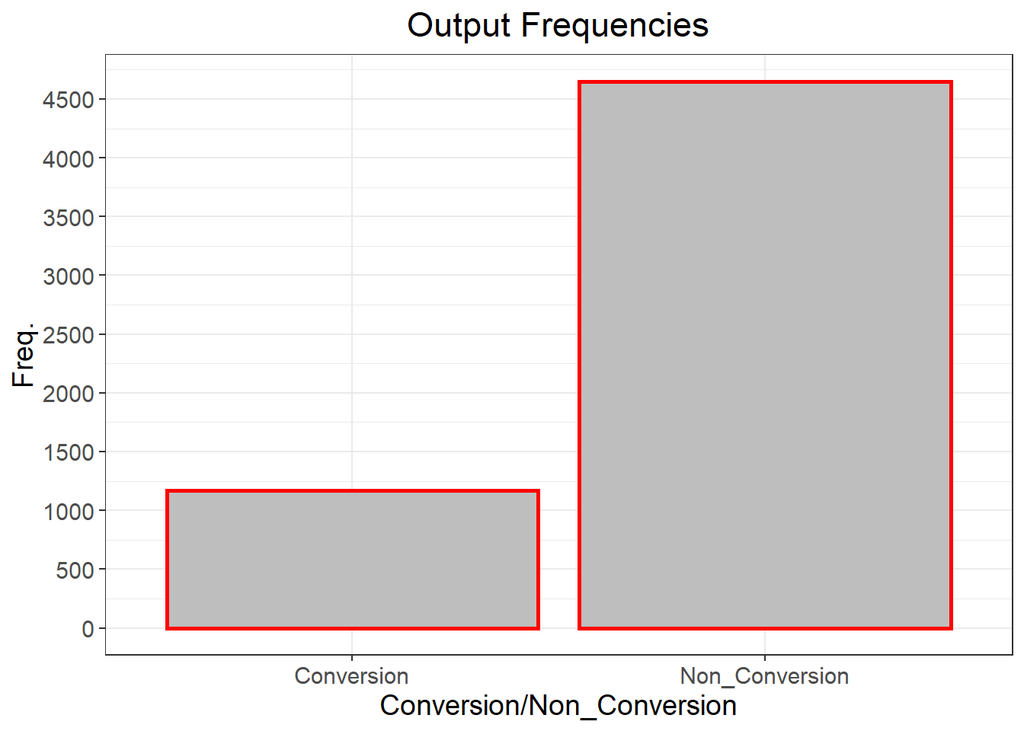

```r
data <- Q3Data %>% mutate(Target=ifelse(Order.Conversion==0,"Non_Conversion","Conversion"))

fre_Output<- data %>% ggplot(aes(x=Target))+geom_bar(fill="grey",col="red", size=1)+theme_bw()+labs(title="Output Frequencies", x="Conversion/Non_Conversion", y="Freq.")+
  theme(text=element_text(size=14))+ theme(plot.title = element_text(hjust=0.5))+scale_y_continuous(breaks=seq(0,6000,by=500))

fre_Output
```

**Graphical Representaion for the input variables**

Categorical variables: country name, item name, shape name. (GREEN Color)

Numerical variables: areaFt. and QtyRequired (BLUE Color)

Remaining variables: 0 & 1 (binary, int).

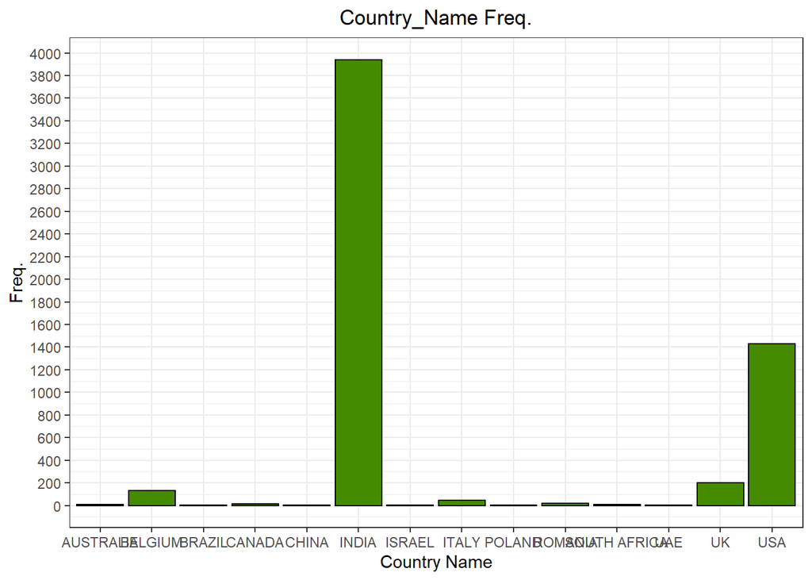

```r
bar1 <- Q3Data %>% ggplot(aes(x=CountryName))+geom_bar(col="black", fill="chartreuse4")+theme_bw()+labs(title="Country_Name Freq.", x="Country Name", y="Freq.")+
  theme(text=element_text(size=11))+ theme(plot.title = element_text(hjust=0.5))+scale_y_continuous(breaks = seq(0,4000,by=200))

bar2 <- Q3Data %>% ggplot(aes(x=ITEM_NAME))+geom_bar(col="black", fill="chartreuse4")+theme_bw()+labs(title="Item_Name Freq.", x="Item Name", y="Freq.")+
  theme(text=element_text(size=11))+ theme(plot.title = element_text(hjust=0.5))+scale_y_continuous(breaks = seq(0,4000,by=200))


bar3 <- Q3Data %>% ggplot(aes(x=ShapeName))+geom_bar(col="black", fill="chartreuse4")+theme_bw()+labs(title="Shape_Name Freq.", x="Shape Name", y="Freq.")+
  theme(text=element_text(size=11))+ theme(plot.title = element_text(hjust=0.5))+scale_y_continuous(breaks = seq(0,6000,by=400))

num1 <- Q3Data %>% ggplot(aes(x=AreaFt))+geom_histogram(binwidth=10,col="black", fill="cadetblue2")+theme_bw()+labs(title="Area (Ft.) Freq.", x="Area (Ft.)", y="Freq.")+
  theme(text=element_text(size=11))+ theme(plot.title = element_text(hjust=0.5))+scale_y_continuous(seq(0,6000,by=500))

num2 <- Q3Data %>% ggplot(aes(x=QtyRequired))+geom_histogram(binwidth=3,col="black", fill="cadetblue2")+theme_bw()+labs(title="Quantity Freq.", x="Quantity Required", y="Freq.")+
  theme(text=element_text(size=11))+ theme(plot.title = element_text(hjust=0.5))+scale_y_continuous(seq(0,6000,by=200))





bar1
```

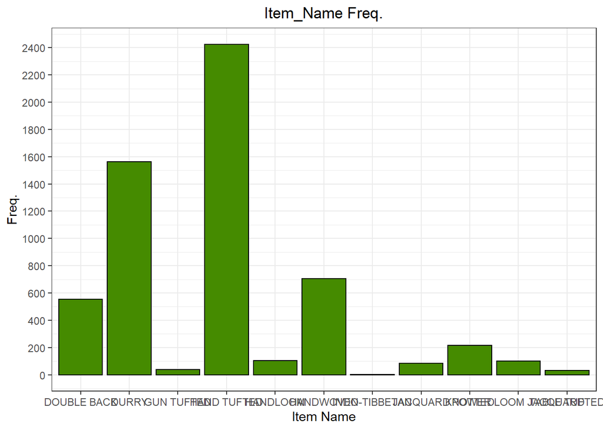

```r
bar2
```

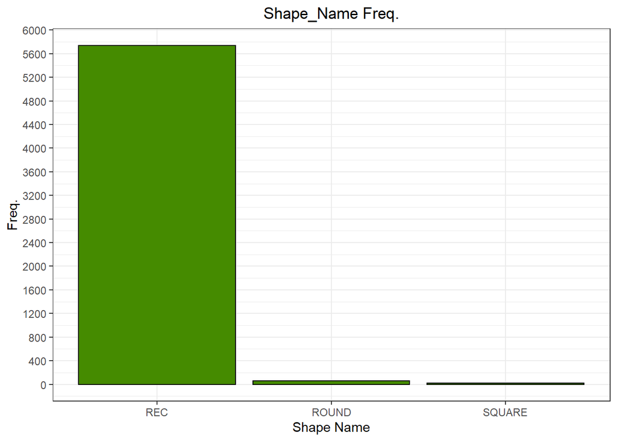

```r
bar3
```

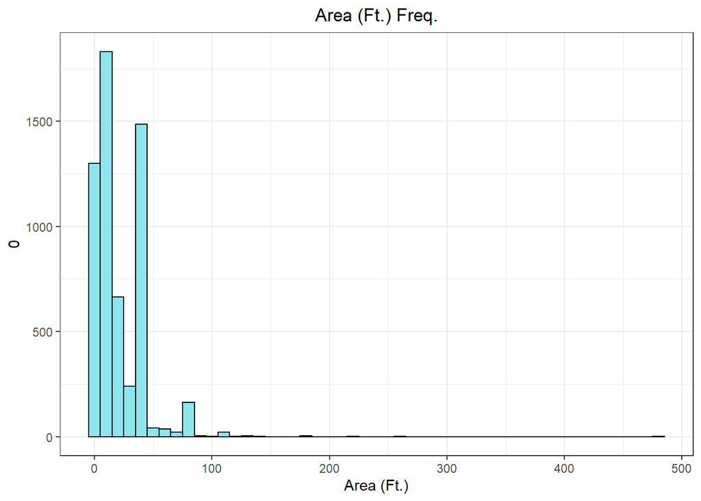

```r
num1
```

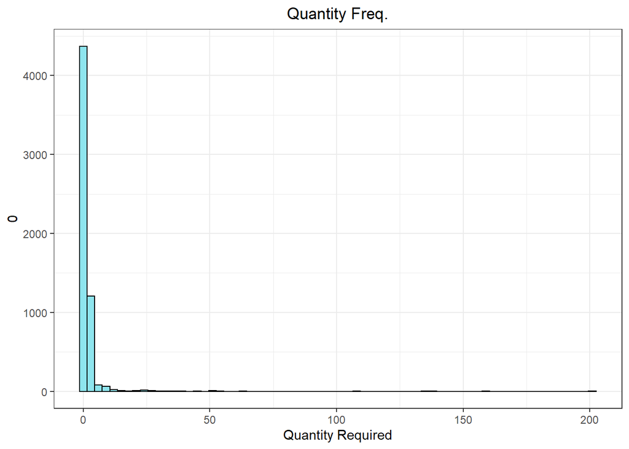

```r
num2
```

**Correlation coffiecinet of Total Area variable to the target variable (Order.Conversion)**

```r
#Area Ft.
cor(Q3Data$AreaFt, Q3Data$Order.Conversion) # =0.3357, positive weak correlation with the target variable. < 0.5
```

```
## [1] 0.3357027
```

```r
# Qty Required
cor(Q3Data$QtyRequired, Q3Data$Order.Conversion) # =0.06, positive weak correlation
```

```
## [1] 0.0567018
```

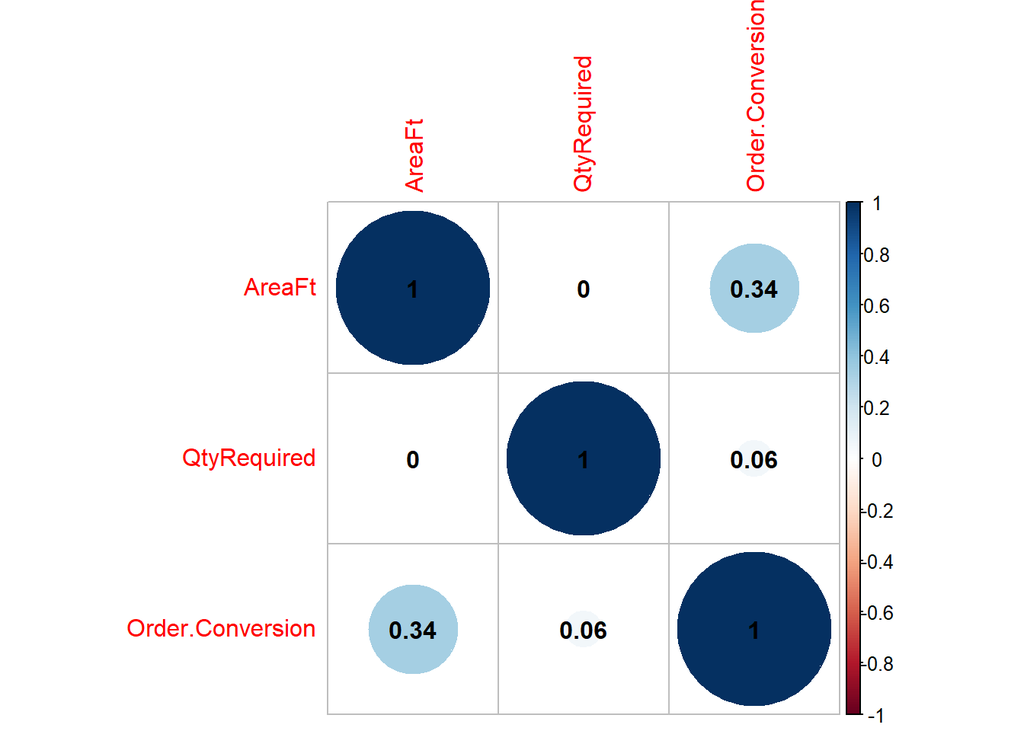

```r
# graphical representation for the correlation of the numerical variables with the target variable

cor_matrix <- Q3Data %>% select(AreaFt, QtyRequired, Order.Conversion) %>%
  cor()

corrplot(cor_matrix, method="circle", size=5, addCoef.col = 1)
```

**Scatter plot for all numericals variable**

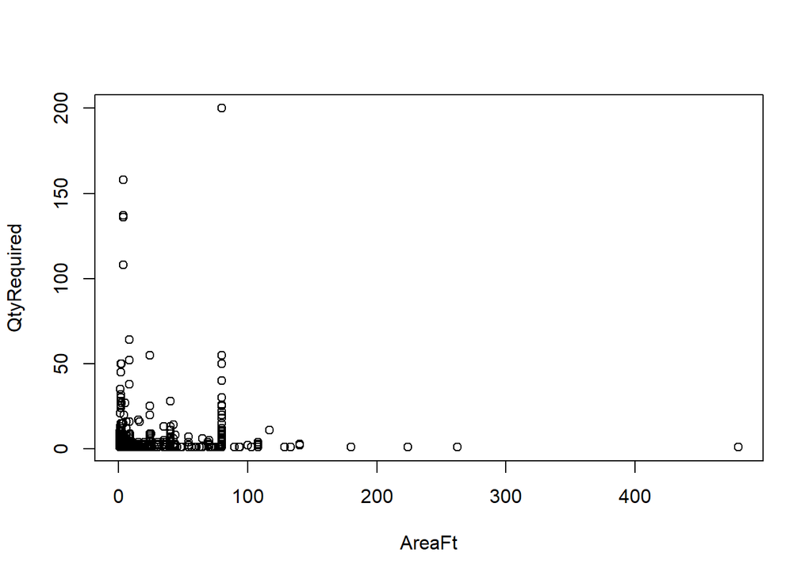

```r
Q3Data %>% select(AreaFt, QtyRequired) %>% plot()
```

*Chi-square test for the categorical variables to determine if they have correlation (association) with the target variable*

Testing the significance of each categorical variable by chi-square test for the following hypothesis:

H0: there is no association between the input variable and Order.Conversion

H1: there is an association between the input variable and Order.Conversion

```r
table1 <- table(Q3Data$CountryName, Q3Data$Order.Conversion)
c1 <- chisq.test(table1, correct=FALSE)$expected
pv1 <- chisq.test(table1, correct=FALSE)$p.value


table2 <- table(Q3Data$ITEM_NAME, Q3Data$Order.Conversion)
c2 <- chisq.test(table2, correct=FALSE)$expected
pv2 <- chisq.test(table2, correct=FALSE)$p.value

table3 <- table(Q3Data$ShapeName, Q3Data$Order.Conversion)
c3 <- chisq.test(table3, correct=FALSE)$expected
pv3 <- chisq.test(table3, correct=FALSE)$p.value
```

1- Variable(Country Name) P-value = 4.3133057^{-135}, <0.05 reject null hypothesis so there is an association

2- Variable(Item Name) P-value = 1.9811662^{-139}, <0.05 reject null hypothesis so there is an association

3- Variable(Shape Name) P-value = 0.0089947, <0.05 reject null hypothesis so there is an association

### 2) Kinds of algorithms to use for this problem

We have our target variable (Conversion Vs. non_conversion) have values 0 or 1, which can be translated into yes and no. This means that our output is categorical. Thus, for this data we are using the classification algorithms [decision tree, random forest, Multi logistic regression, nueral network]. We will select the best model based on the F-Score resulted from the confusion matrix. The reason for selecting the F.Score as the determant measure is because both precision and recall are important in this case. the false positive and false negative are both sensative for the case of conversion/non.conversion, thus they both are taken into consideration.

After the classification models with this given output variable. Clustering method will be implemented in order to cluser the customers when the output variable is unknown.

### 3) Classification Modeling

For this question, we have the target variable (order.conversion), so we are performing all classification models that we learned. (decision tree, random forest, logistic regression, nueral network, and ada boost)

For assessing each model, we used the Fscore to judge which model gives the best result. We chose the Fscore because both the precison and recall are important.

**UNBALANCED DATA**

*1/ Decision Tree*

```r
Q3Data$Order.Conversion <- as.factor(Q3Data$Order.Conversion) # output variable as a factor.

DATA <- Q3Data

# Confusion matrix evaluation.
EvaluationMeasure <- function(CM)
{

  TP <- CM[1,1]
  FN <- CM[1,2]
  FP <- CM[2,1]
  TN <- CM[2,2]

  Percision <- (TP)/(TP+FP)
  Recall <- (TP)/(TP+FN)
  Fscore <- (2*Recall*Percision)/(Recall + Percision)
  Measures <- cbind(Fscore)

  return(Measures)
}

set.seed(134)
# 2 variables were dropped because of its high correlation. (others & Square)
# K-fold cross-validation
K <- 5
indx <- sample(K,size=nrow(DATA), replace=TRUE, prob=c(0.1, 0.1, 0.1, 0.1, 0.1))
MyFormula <- Order.Conversion~ USA + UK + Italy + Belgium + Romania + Australia + India + QtyRequired + Hand.Tufted + Durry + Double.Back + Hand.Woven + Knotted + Jacquard + Handloom + REC + Round + AreaFt

treetype <- c("gini", "information")
CP <- c(-1, 0, 0.01, 0.05, 0.1)
MB <- c(0, 5, 10, 20, 50)
MS <- c(0, 10, 20, 50, 100)

err <- c()
for (i in 1:K)
{
  Error <- c()
  training <- DATA[indx != i,]
  testing <- DATA[indx == i,]
  idx <- sample(2,size=nrow(training), replace=TRUE, prob=c(.8, .2))
  train <- training[idx==1,]
  validation <- training[idx==2,]
  for (tt in 1:length(treetype))
  {
    for (cp in 1:length(CP))
    {
      for (mb in 1:length(MB))
      {
        for (ms in 1:length(MS))
        {
          mytree <- rpart(MyFormula, data=train, parms = list(split=treetype[tt]), control=rpart.control(minsplit = MS[ms], minbucket = MB[mb], cp=CP[cp]))
          pred <- predict(mytree, newdata=validation, type="class")
          CM <- table(validation$Order.Conversion, pred,  dnn=c("Actual", "Predicted"))
          Measures <- as.data.frame(EvaluationMeasure(CM))
          nv <- c(treetype[tt], MS[ms], MB[mb], CP[cp], Measures$Fscore)
          #print(nv)
          Error <- rbind(Error, nv)
        }
      }
    }
  }
  #print(i)
  colnames(Error) <- c("treetype", "MS", "MB","CP","Fscore")
  Error <- as.data.frame(Error)
  Error1 <- Error %>% arrange(desc(Fscore))
  #print(Error1[1,])
  mytree1 <- rpart(MyFormula, data=training, parms = list(split=Error1[1, 1]), control=rpart.control(minsplit = Error1[1, 2], minbucket = Error1[1, 3], cp=Error1[1, 4]))
  predict_test<- predict(mytree1, newdata=testing, type="class")
  CM <- table(testing$Order.Conversion, predict_test,  dnn=c("Actual", "Predicted"))
  Measures <- as.data.frame(EvaluationMeasure(CM))
  err <- cbind(err, Measures$Fscore)
}
print(mean((err)))
```

```
## [1] 0.9480373
```

```r
print(sd(err))
```

```
## [1] 0.007675299
```

**So the Fscore for decsision tree = 0.95**

*2/ Random Forest*

```r
set.seed(134)
# K-fold cross-validation

K <- 5
indx <- sample(K,size=nrow(DATA), replace=TRUE, prob=c(0.1, 0.1, 0.1, 0.1, 0.1))


MyFormula <- Order.Conversion~ USA + UK + Italy + Belgium + Romania + Australia + India + QtyRequired + Hand.Tufted+
  Durry + Double.Back + Hand.Woven + Knotted + Jacquard + Handloom + REC + Round + AreaFt

NoTree <- c(10, 50, 100, 150)
Mtry <- c(7, 10, 25, 5)

err <- c()
for (i in 1:K)
{
  Error <- c()
  for (j in 1:length(NoTree))
  {
    for (c in 1:length(Mtry))
    {
      RF <- randomForest(MyFormula, data=DATA, ntree = NoTree[j], mtry = Mtry[c], proximity = TRUE, importance=TRUE)
      CM <- table(DATA$Order.Conversion, RF$predicted,  dnn=c("Actual", "Predicted"))
      Measures <- as.data.frame(EvaluationMeasure(CM))
      nv <- c(NoTree[j], Mtry[c], Measures$Fscore)
      Error <- rbind(Error, nv)
    }
  }
  colnames(Error) <- c("NoTree", "Mtry","Fscore")
  Error <- as.data.frame(Error)
  Error1 <- Error %>% arrange(desc(Fscore))
  #print(Error1[1,])
  RF1 <- randomForest(MyFormula, data=DATA, ntree = Error1[1,1], mtry = Error1[1,2])
  CM <- table(DATA$Order.Conversion, RF1$predicted,  dnn=c("Actual", "Predicted"))
  Measures <- as.data.frame(EvaluationMeasure(CM))
  err <- cbind(err, Measures$Fscore)
}

print(mean((err)))
```

```
## [1] 0.9520034
```

```r
print(sd(err))
```

```
## [1] 0.0005684913
```

**So the Fscore for Random Forest = 0.95**

*3/ Logistic Regression*

```r
set.seed(256)
MyFormula <- Order.Conversion~ USA + UK + Italy + Belgium + Romania + Australia + India + QtyRequired + Hand.Tufted+
  Durry + Double.Back + Hand.Woven + Knotted + Jacquard + Handloom + REC + Round + AreaFt
indx <- sample(2,size=nrow(DATA), replace=TRUE, prob=c(0.8, 0.2))
train <- DATA[indx==1,]
test <- DATA[indx==2,]
MNL <- glm(MyFormula, data=train, family = "binomial")
summary(MNL)
```

```
##
## Call:
## glm(formula = MyFormula, family = "binomial", data = train)
##
## Deviance Residuals:
##     Min       1Q   Median       3Q      Max
## -2.9769  -0.5641  -0.2678  -0.1817   2.9570
##
## Coefficients:
##              Estimate Std. Error z value Pr(>|z|)
## (Intercept)  4.672559   0.737898   6.332 2.42e-10 ***
## USA         -1.768314   0.393721  -4.491 7.08e-06 ***
## UK          -1.425779   0.423404  -3.367 0.000759 ***
## Italy       -3.290600   0.671130  -4.903 9.43e-07 ***
## Belgium      2.502339   0.552484   4.529 5.92e-06 ***
## Romania      0.189782   0.674429   0.281 0.778406
## Australia   -0.534061   0.895108  -0.597 0.550745
## India       -3.321133   0.394729  -8.414  < 2e-16 ***
## QtyRequired  0.010157   0.006971   1.457 0.145110
## Hand.Tufted -4.161723   0.239045 -17.410  < 2e-16 ***
## Durry       -3.910404   0.241869 -16.167  < 2e-16 ***
## Double.Back -4.274342   0.291105 -14.683  < 2e-16 ***
## Hand.Woven  -4.695254   0.287624 -16.324  < 2e-16 ***
## Knotted     -1.419478   0.285172  -4.978 6.44e-07 ***
## Jacquard    -3.951700   0.399313  -9.896  < 2e-16 ***
## Handloom    -3.883113   0.382004 -10.165  < 2e-16 ***
## REC         -1.274046   0.595484  -2.140 0.032394 *
## Round       -0.697712   0.698460  -0.999 0.317829
## AreaFt       0.060747   0.002699  22.506  < 2e-16 ***
## ---
## Signif. codes:  0 '***' 0.001 '**' 0.01 '*' 0.05 '.' 0.1 ' ' 1
##
## (Dispersion parameter for binomial family taken to be 1)
##
##     Null deviance: 4734.9  on 4630  degrees of freedom
## Residual deviance: 3053.2  on 4612  degrees of freedom
## AIC: 3091.2
##
## Number of Fisher Scoring iterations: 6
```

```r
PRED <- predict(MNL, newdata=test, type="response")

class <- ifelse(PRED >= 0.5, "1","0")
class
```

[output not shown]

[output cut: 95 more lines]

[output not shown]

```r
CM <- table(test$Order.Conversion, class,  dnn=c("Actual", "Predicted"))
Measures <- as.data.frame(EvaluationMeasure(CM))
print(Measures$Fscore)
```

```
## [1] 0.9213147
```

**So the Fscore for Logisitc regression = 0.92**

*4/ Nueral Network*

```r
# first normalizing numerical variables.

myscale <- function(x)
{
  (x-min(x))/(max(x)-min(x))
}


NN_DATA <- DATA %>% mutate_if(is.numeric, myscale)
summary(NN_DATA) # showing normalized data
```

```
##  CustomerCode        CountryName        USA               UK
##  Length:5820        INDIA  :3941   Min.   :0.0000   Min.   :0.00000
##  Class :character   USA    :1430   1st Qu.:0.0000   1st Qu.:0.00000
##  Mode  :character   UK     : 203   Median :0.0000   Median :0.00000
##                     BELGIUM: 132   Mean   :0.2474   Mean   :0.03488
##                     ITALY  :  45   3rd Qu.:0.0000   3rd Qu.:0.00000
##                     ROMANIA:  20   Max.   :1.0000   Max.   :1.00000
##                     (Other):  49
##      Italy             Belgium           Romania           Australia
##  Min.   :0.000000   Min.   :0.00000   Min.   :0.000000   Min.   :0.000000
##  1st Qu.:0.000000   1st Qu.:0.00000   1st Qu.:0.000000   1st Qu.:0.000000
##  Median :0.000000   Median :0.00000   Median :0.000000   Median :0.000000
##  Mean   :0.007732   Mean   :0.02268   Mean   :0.003436   Mean   :0.001718
##  3rd Qu.:0.000000   3rd Qu.:0.00000   3rd Qu.:0.000000   3rd Qu.:0.000000
##  Max.   :1.000000   Max.   :1.00000   Max.   :1.000000   Max.   :1.000000
##
##      India         QtyRequired             ITEM_NAME     Hand.Tufted
##  Min.   :0.0000   Min.   :0.000000   HAND TUFTED:2425   Min.   :0.0000
##  1st Qu.:0.0000   1st Qu.:0.000000   DURRY      :1563   1st Qu.:0.0000
##  Median :1.0000   Median :0.000000   HANDWOVEN  : 705   Median :0.0000
##  Mean   :0.6771   Mean   :0.004899   DOUBLE BACK: 554   Mean   :0.4167
##  3rd Qu.:1.0000   3rd Qu.:0.000000   KNOTTED    : 217   3rd Qu.:1.0000
##  Max.   :1.0000   Max.   :1.000000   HANDLOOM   : 103   Max.   :1.0000
##                                      (Other)    : 253
##      Durry         Double.Back        Hand.Woven        Knotted
##  Min.   :0.0000   Min.   :0.00000   Min.   :0.0000   Min.   :0.00000
##  1st Qu.:0.0000   1st Qu.:0.00000   1st Qu.:0.0000   1st Qu.:0.00000
##  Median :0.0000   Median :0.00000   Median :0.0000   Median :0.00000
##  Mean   :0.2686   Mean   :0.09519   Mean   :0.1211   Mean   :0.03729
##  3rd Qu.:1.0000   3rd Qu.:0.00000   3rd Qu.:0.0000   3rd Qu.:0.00000
##  Max.   :1.0000   Max.   :1.00000   Max.   :1.0000   Max.   :1.00000
##
##     Jacquard          Handloom          Other          ShapeName
##  Min.   :0.00000   Min.   :0.0000   Min.   :0.00000   REC   :5741
##  1st Qu.:0.00000   1st Qu.:0.0000   1st Qu.:0.00000   ROUND :  57
##  Median :0.00000   Median :0.0000   Median :0.00000   SQUARE:  22
##  Mean   :0.01443   Mean   :0.0177   Mean   :0.02904
##  3rd Qu.:0.00000   3rd Qu.:0.0000   3rd Qu.:0.00000
##  Max.   :1.00000   Max.   :1.0000   Max.   :1.00000
##
##       REC             Round              Square            AreaFt
##  Min.   :0.0000   Min.   :0.000000   Min.   :0.00000   Min.   :0.00000
##  1st Qu.:1.0000   1st Qu.:0.000000   1st Qu.:0.00000   1st Qu.:0.01113
##  Median :1.0000   Median :0.000000   Median :0.00000   Median :0.02156
##  Mean   :0.9864   Mean   :0.009794   Mean   :0.00378   Mean   :0.04358
##  3rd Qu.:1.0000   3rd Qu.:0.000000   3rd Qu.:0.00000   3rd Qu.:0.08167
##  Max.   :1.0000   Max.   :1.000000   Max.   :1.00000   Max.   :1.00000
##
##  Order.Conversion
##  0:4651
##  1:1169
##
##
##
##
##
```

```r
set.seed(1234)
MyFormula <- Order.Conversion~ USA + UK + Italy + Belgium + Romania + Australia + India + QtyRequired + Hand.Tufted+
  Durry + Double.Back + Hand.Woven + Knotted + Jacquard + Handloom + REC + Round + AreaFt



# corss validation for pruning the parameter (size & decay).
K <- 5
indx <- sample(K,size=nrow(NN_DATA), replace=TRUE, prob=c(0.1, 0.1, 0.1, 0.1, 0.1))


MyFormula <- Order.Conversion~ USA + UK + Italy + Belgium + Romania + Australia + India + QtyRequired + Hand.Tufted+
  Durry + Double.Back + Hand.Woven + Knotted + Jacquard + Handloom + REC + Round + AreaFt

SIZE <- c(9, 11, 13, 15, 17)
DECAY <- c(0, 0.01, 0.05, 0.1, 0.5)


err <- c()
for (k in 1:K)
{
  Error <- c()
  training <- NN_DATA[indx != i,]
  testing <- NN_DATA[indx == i,]
  idx <- sample(2,size=nrow(training), replace=TRUE, prob=c(.8, .2))
  train <- training[idx==1,]
  validation <- training[idx==2,]
  for (i in 1:length(SIZE))
  {
    for (j in 1:length(DECAY))
         {
           myNet <- nnet(MyFormula, data=train, linout = F, size = SIZE[i], decay = DECAY[j], maxit = 1000)
           pred <- predict(myNet, newdata=validation, type="class")
           CM <- table(validation$Order.Conversion, pred,  dnn=c("Actual", "Predicted"))
           Measures <- as.data.frame(EvaluationMeasure(CM))
           nv <- c(SIZE[i], DECAY[j], Measures$Fscore)
           #print(nv)
           Error <- rbind(Error, nv)
           }
  }
 # print(i)
  colnames(Error) <- c("SIZE", "DECAY","Fscore")
  Error <- as.data.frame(Error)
  Error1 <- Error %>% arrange(desc(Fscore))
  #print(Error1[1,])
  myNet1 <- nnet(MyFormula, data=training, linout = F, size = Error1[1, 1], decay = Error1[1, 2], maxit = 1000)
  predict_test<- predict(myNet1, newdata=testing, type="class")
  CM <- table(testing$Order.Conversion, predict_test,  dnn=c("Actual", "Predicted"))
  Measures <- as.data.frame(EvaluationMeasure(CM))
  err <- cbind(err, Measures$Fscore)

}
```

[output not shown]

```r
print(mean((err)))
```

```
## [1] 0.9420311
```

```r
print(sd(err))
```

```
## [1] 0.003231223
```

**So the Fscore for nueral network = 0.94**

*5/ Ada Boost*

```r
K <- 5
indx <- sample(K,size=nrow(NN_DATA), replace=TRUE, prob=c(0.1, 0.1, 0.1, 0.1, 0.1))
NN_DATA$Order.Conversion<-ifelse(NN_DATA$Order.Conversion==1,1,-1)

TD <- c(3, 5, 7, 9, 11)
NR <- c(10, 50, 100, 200, 500)


err <- c()
for (k in 1:K)
{
  Error <- c()
  training <- NN_DATA[indx != i,]
  testing <- NN_DATA[indx == i,]
  idx <- sample(2,size=nrow(training), replace=TRUE, prob=c(.8, .2))
  train <- training[idx==1,]
  validation <- training[idx==2,]

  trainingY <- training$Order.Conversion
  trainingX <- subset(training, select = -c(Order.Conversion))

  testingY <- testing$Order.Conversion
  testingX <- subset(testing, select = -c(Order.Conversion))

  trainY <- train$Order.Conversion
  trainX <- subset(train, select = -c(Order.Conversion))

  validationY <- validation$Order.Conversion
  validationX <- subset(validation, select = -c(Order.Conversion))

  for (i in 1:length(TD))
  {
    for (j in 1:length(NR))
    {
      ada = adaboost(data.matrix(trainX), trainY, tree_depth = TD[i], n_rounds = NR[j])
      pred <- predict(ada, data.matrix(validationX))
      CM <- table(validation$Order.Conversion, pred,  dnn=c("Actual", "Predicted"))
      Measures <- as.data.frame(EvaluationMeasure(CM))
      nv <- c(TD[i], NR[j], Measures$Fscore)
      #print(nv)
      Error <- rbind(Error, nv)
    }
  }
  #print(i)
  colnames(Error) <- c("tree_depth", "n_rounds","Fscore")
  Error <- as.data.frame(Error)
  Error1 <- Error %>% arrange(desc(Fscore))
  #print(Error1[1,])
  ada1 = adaboost(data.matrix(trainingX), trainingY, tree_depth = Error1[1, 1], n_rounds = Error1[1, 2])
  pred <- predict(ada, data.matrix(validationX))

  predict_test<- predict(ada, data.matrix(testingX))

  CM <- table(testing$Order.Conversion, predict_test,  dnn=c("Actual", "Predicted"))
  Measures <- as.data.frame(EvaluationMeasure(CM))
  err <- cbind(err, Measures$Fscore)

}

print(mean((err)))
```

```
## [1] 0.8405566
```

```r
print(sd(err))
```

```
## [1] 0.03346996
```

*We conclude that either decision tree or random forest gives the best modeling because of the highest Fscore of 0.95 for UNBALANCED DATA*

**BALANCED DATA**

```r
summary(Q3Data$Order.Conversion) # unbalanced for each class.
```

```
##    0    1
## 4651 1169
```

```r
library(ROSE)

DATA <- ovun.sample(Order.Conversion~., data=Q3Data, method="both", N=6500)$data
summary(DATA$Order.Conversion)
```

```
##    0    1
## 3322 3178
```

*1/ Decision Tree*

```r
set.seed(134)


# K-fold cross-validation

K <- 5
indx <- sample(K,size=nrow(DATA), replace=TRUE, prob=c(0.1, 0.1, 0.1, 0.1, 0.1))
MyFormula <- Order.Conversion~ USA + UK + Italy + Belgium + Romania + Australia + India + QtyRequired + Hand.Tufted+
  Durry + Double.Back + Hand.Woven + Knotted + Jacquard + Handloom + REC + Round + AreaFt

treetype <- c("gini", "information")
CP <- c(-1, 0, 0.01, 0.05, 0.1)
MB <- c(0, 5, 10, 20, 50)
MS <- c(0, 10, 20, 50, 100)

err <- c()
for (i in 1:K)
{
  Error <- c()
  training <- DATA[indx != i,]
  testing <- DATA[indx == i,]
  idx <- sample(2,size=nrow(training), replace=TRUE, prob=c(.8, .2))
  train <- training[idx==1,]
  validation <- training[idx==2,]
  for (tt in 1:length(treetype))
  {
    for (cp in 1:length(CP))
    {
      for (mb in 1:length(MB))
      {
        for (ms in 1:length(MS))
        {
          mytree <- rpart(MyFormula, data=train, parms = list(split=treetype[tt]), control=rpart.control(minsplit = MS[ms], minbucket = MB[mb], cp=CP[cp]))
          pred <- predict(mytree, newdata=validation, type="class")
          CM <- table(validation$Order.Conversion, pred,  dnn=c("Actual", "Predicted"))
          Measures <- as.data.frame(EvaluationMeasure(CM))
          nv <- c(treetype[tt], MS[ms], MB[mb], CP[cp], Measures$Fscore)
          #print(nv)
          Error <- rbind(Error, nv)
        }
      }
    }
  }
  #print(i)
  colnames(Error) <- c("treetype", "MS", "MB","CP","Fscore")
  Error <- as.data.frame(Error)
  Error1 <- Error %>% arrange(desc(Fscore))
  #print(Error1[1,])
  mytree1 <- rpart(MyFormula, data=training, parms = list(split=Error1[1, 1]), control=rpart.control(minsplit = Error1[1, 2], minbucket = Error1[1, 3], cp=Error1[1, 4]))
  predict_test<- predict(mytree1, newdata=testing, type="class")
  CM <- table(testing$Order.Conversion, predict_test,  dnn=c("Actual", "Predicted"))
  Measures <- as.data.frame(EvaluationMeasure(CM))
  err <- cbind(err, Measures$Fscore)
}

print(mean((err)))
```

```
## [1] 0.8815106
```

```r
print(sd(err))
```

```
## [1] 0.008442166
```

*2/ Random Forest*

```r
set.seed(134)
# K-fold cross-validation
K <- 5
indx <- sample(K,size=nrow(DATA), replace=TRUE, prob=c(0.1, 0.1, 0.1, 0.1, 0.1))


MyFormula <- Order.Conversion~ USA + UK + Italy + Belgium + Romania + Australia + India + QtyRequired + Hand.Tufted+
  Durry + Double.Back + Hand.Woven + Knotted + Jacquard + Handloom + REC + Round + AreaFt


NoTree <- c(10, 50, 100, 150)
Mtry <- c(7, 10, 25, 5)

err <- c()
for (i in 1:K)
{
  Error <- c()
  for (j in 1:length(NoTree))
  {
    for (c in 1:length(Mtry))
    {
      RF <- randomForest(MyFormula, data=DATA, ntree = NoTree[j], mtry = Mtry[c], proximity = TRUE, importance=TRUE)
      CM <- table(DATA$Order.Conversion, RF$predicted,  dnn=c("Actual", "Predicted"))
      Measures <- as.data.frame(EvaluationMeasure(CM))
      nv <- c(NoTree[j], Mtry[c], Measures$Fscore)
      Error <- rbind(Error, nv)
    }
  }
  colnames(Error) <- c("NoTree", "Mtry","Fscore")
  Error <- as.data.frame(Error)
  Error1 <- Error %>% arrange(desc(Fscore))
  print(Error1[1,])
  RF1 <- randomForest(MyFormula, data=DATA, ntree = Error1[1,1], mtry = Error1[1,2])
  CM <- table(DATA$Order.Conversion, RF1$predicted,  dnn=c("Actual", "Predicted"))
  Measures <- as.data.frame(EvaluationMeasure(CM))
  err <- cbind(err, Measures$Fscore)
}
```

```
##       NoTree Mtry    Fscore
## nv.10    100   25 0.8848485
##       NoTree Mtry    Fscore
## nv.13    150   10 0.8847361
##      NoTree Mtry    Fscore
## nv.9    100   10 0.8846978
##       NoTree Mtry    Fscore
## nv.10    100   25 0.8849149
##      NoTree Mtry    Fscore
## nv.9    100   10 0.8842857
```

```r
print(mean((err)))
```

```
## [1] 0.8828017
```

```r
print(sd(err))
```

```
## [1] 0.0008660636
```

*So the Fscore for random forest = 0.88*

*3/ Logistic Regression*

```r
set.seed(256)
MyFormula <- Order.Conversion~ USA + UK + Italy + Belgium + Romania + Australia + India + QtyRequired + Hand.Tufted+
  Durry + Double.Back + Hand.Woven + Knotted + Jacquard + Handloom + REC + Round + AreaFt
indx <- sample(2,size=nrow(DATA), replace=TRUE, prob=c(0.8, 0.2))
train <- DATA[indx==1,]
test <- DATA[indx==2,]
MNL <- glm(MyFormula, data=train, family = "binomial")
summary(MNL)
```

```
##
## Call:
## glm(formula = MyFormula, family = "binomial", data = train)
##
## Deviance Residuals:
##     Min       1Q   Median       3Q      Max
## -4.0992  -0.7394  -0.2881   0.7047   2.3902
##
## Coefficients:
##             Estimate Std. Error z value Pr(>|z|)
## (Intercept)  8.94315    1.14960   7.779 7.29e-15 ***
## USA         -2.07034    0.36565  -5.662 1.50e-08 ***
## UK          -1.19219    0.39727  -3.001 0.002691 **
## Italy       -2.92797    0.66910  -4.376 1.21e-05 ***
## Belgium      2.77774    0.58922   4.714 2.43e-06 ***
## Romania      0.28735    0.65985   0.435 0.663214
## Australia   -0.95947    0.99710  -0.962 0.335916
## India       -3.52251    0.36523  -9.645  < 2e-16 ***
## QtyRequired  0.09350    0.01220   7.662 1.83e-14 ***
## Hand.Tufted -4.86915    0.28006 -17.386  < 2e-16 ***
## Durry       -4.53745    0.28153 -16.117  < 2e-16 ***
## Double.Back -4.81245    0.30562 -15.746  < 2e-16 ***
## Hand.Woven  -5.45933    0.30962 -17.633  < 2e-16 ***
## Knotted     -1.99446    0.32261  -6.182 6.32e-10 ***
## Jacquard    -4.71847    0.37696 -12.517  < 2e-16 ***
## Handloom    -4.97494    0.36709 -13.552  < 2e-16 ***
## REC         -3.57692    1.05699  -3.384 0.000714 ***
## Round       -3.60466    1.11607  -3.230 0.001239 **
## AreaFt       0.06012    0.00229  26.260  < 2e-16 ***
## ---
## Signif. codes:  0 '***' 0.001 '**' 0.01 '*' 0.05 '.' 0.1 ' ' 1
##
## (Dispersion parameter for binomial family taken to be 1)
##
##     Null deviance: 7173.1  on 5176  degrees of freedom
## Residual deviance: 4493.6  on 5158  degrees of freedom
## AIC: 4531.6
##
## Number of Fisher Scoring iterations: 6
```

```r
PRED <- predict(MNL, newdata=test, type="response")

class <- ifelse(PRED >= 0.5, "1","0")
class
```

[output not shown]

[output cut: 111 more lines]

[output not shown]

```r
CM <- table(test$Order.Conversion, class,  dnn=c("Actual", "Predicted"))
Measures <- as.data.frame(EvaluationMeasure(CM))
print(Measures$Fscore)
```

```
## [1] 0.8241135
```